# Lecture 8. Transformers

**Maybe attention is all you need**

Joaquin Vanschoren

## Overview

- Basics: word embeddings
  - Word2Vec, FastText, GloVe
- Sequence-to-sequence and autoregressive models
- Self-attention and transformer models
- Vision Transformers

## Bag of word representation

- First, build a *vocabulary* of all occuring words. Maps every word to an index.
- Represent each document as an $N$ dimensional vector (top-$N$ most frequent words)
  - One-hot (sparse) encoding: 1 if the word occurs in the document
- Destroys the order of the words in the text (hence, a 'bag' of words)

[figure not shown]

### Text preprocessing pipelines

- Tokenization: how to you split text into words / tokens?
- Stemming: naive reduction to word stems. E.g. 'the meeting' to 'the meet'
- Lemmatization: NLP-based reduction, e.g. distinguishes between nouns and verbs
- Discard stop words ('the', 'an',...)
- Only use $N$ (e.g. 10000) most frequent words, or a hash function
- n-grams: Use combinations of $n$ adjacent words next to individual words
  - e.g. 2-grams: "awesome movie", "movie with", "with creative", ...
- Character n-grams: combinations of $n$ adjacent letters: 'awe', 'wes', 'eso',...
- Subword tokenizers: graceful splits "unbelievability" -> un, believ, abil, ity
- Useful libraries: [nltk](https://www.nltk.org/), [spaCy](https://spacy.io/), [gensim](https://radimrehurek.com/gensim/), [HuggingFace tokenizers](https://huggingface.co/docs/tokenizers/index),...

## Neural networks on bag of words

- We can build neural networks on bag-of-word vectors
  - Do a one-hot-encoding with 10000 most frequent words
  - Simple model with 2 dense layers, ReLU activation, dropout

```
self.model = nn.Sequential(
    nn.Linear(10000, 16),
    nn.ReLU(),
    nn.Dropout(0.5),
    nn.Linear(16, 16),
    nn.ReLU(),
    nn.Dropout(0.5),
    nn.Linear(16, 1)
)
```

### Evaluation

- IMDB dataset of movie reviews (label is 'positive' or 'negative')
- Take a validation set of 10,000 samples from the training set
- Works prety well (88% Acc), but overfits easily

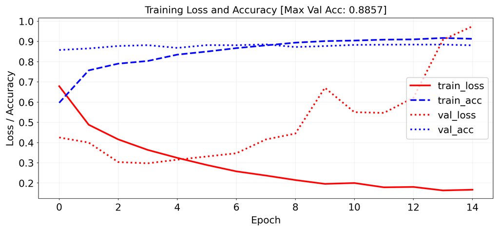

```
`Trainer.fit` stopped: `max_epochs=15` reached.
```

#### Predictions

```
Review 0:
 [START] please give this one a miss br br [UNK] [UNK] and the rest of the cast rendered terrible performances the show is flat flat flat br br i don't know how michael madison could have allowed this one on his plate he almost seemed to know this wasn't going to work out and his performance was qui…
Predicted positiveness: 0.15110373

Review 16:
 [START] from 1996 first i watched this movie i feel never reach the end of my satisfaction i feel that i want to watch more and more until now my god i don't believe it was ten years ago and i can believe that i almost remember every word of the dialogues i love this movie and i love this novel abs…
Predicted positiveness: 0.99687344

Review X:
 [START] the restaurant is not too terrible
Predicted positiveness: 0.8728
```

## Word Embeddings

- A word embedding is a numeric vector representation of a word
  - Can be manual or *learned* from an existing representation (e.g. one-hot)

[figure not shown]

### Learning embeddings from scratch

- Input layer uses fixed length documents (with 0-padding).
- Add an *embedding layer* to learn the embedding
  - Create $n$-dimensional one-hot encoding.
  - To learn an $m$-dimensional embedding, use $m$ hidden nodes. Weight matrix $W^{n x m}$
  - Linear activation function: $\mathbf{X}_{embed} = W \mathbf{X}_{orig}$.
- Combine all word embeddings into a document embedding (e.g. global pooling).
- Add layers to map word embeddings to the output. Learn embedding weights from data.

[figure not shown]

Let's try this:

```
max_length = 100 # pad documents to a maximum number of words
vocab_size = 10000 # vocabulary size
embedding_length = 20 # embedding length (more would be better)

self.model = nn.Sequential(
    nn.Embedding(vocab_size, embedding_length),
    nn.AdaptiveAvgPool1d(1),  # global average pooling over sequence
    nn.Linear(embedding_length, 1),
)
```

- Training on the IMDB dataset: slightly worse than using bag-of-words?
  - Embedding of dim 20 is very small, should be closer to 100 (or 300)
  - We don't have enough data to learn a really good embedding from scratch

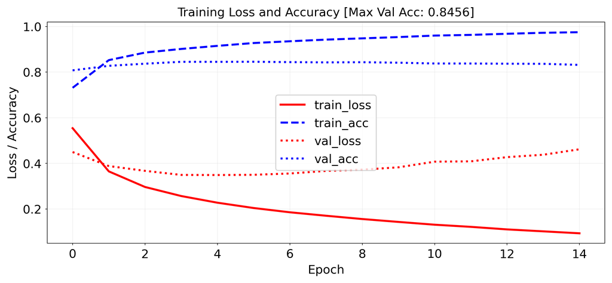

```
`Trainer.fit` stopped: `max_epochs=15` reached.
```

### Pre-trained embeddings

- With more data we can build better embeddings, but we also need more labels
- Solution: transfer learning! Learn embedding on auxiliary task that doesn't require labels
  - E.g. given a word, predict the surrounding words.
  - Also called self-supervised learning. Supervision is provided by data itself
- Freeze embedding weights to produce simple word embeddings, or finetune to a new tasks
- Most common approaches:
  - Word2Vec: Learn neural embedding for a word based on surrounding words
  - FastText: learns embedding for character n-grams
    - Can also produce embeddings for new, unseen words
  - GloVe (Global Vector): Count co-occurrences of words in a matrix
    - Use a low-rank approximation to get a latent vector representation

#### Word2Vec

- Move a window over text to get $C$ context words ($V$-dim one-hot encoded)
- Add embedding layer with $N$ linear nodes, global average pooling, and softmax layer(s)
- CBOW: predict word given context, use weights of last layer $W^{'}_{NxV}$ as embedding
- Skip-Gram: predict context given word, use weights of first layer $W^{T}_{VxN}$ as embedding
  - Scales to larger text corpora, learns relationships between words better

[figure not shown]

#### Word2Vec properties

- Word2Vec happens to learn [interesting relationships](https://www.aclweb.org/anthology/N13-1090/) between words
  - Simple vector arithmetic can map words to plurals, conjugations, gender analogies,...
  - e.g. Gender relationships: $vec_{king} - vec_{man} + vec_{woman} \sim vec_{queen}$
  - PCA applied to embeddings shows Country - Capital relationship
- Careful: embeddings can capture [gender and other biases](https://arxiv.org/abs/1607.06520) present in the data.
  - Important unsolved problem!

[figure not shown]

### Doc2Vec

- Alternative way to combine word embeddings (instead of global pooling)
- Adds a paragraph (or document) embedding: learns how paragraphs (or docs) relate to each other
  - Captures document-level semantics: context and meaning of entire document
- Can be used to determine semantic similarity between documents.

[figure not shown]

#### FastText

- Limitations of Word2Vec:
  - Cannot represent new (out-of-vocabulary) words
  - Similar words are learned independently: less efficient (no parameter sharing)
    - E.g. 'meet' and 'meeting'
- FastText: same model, but uses *character n-grams*
  - Words are represented by all character n-grams of length 3 to 6
    - "football" 3-grams: <fo, foo, oot, otb, tba, bal, all, ll>
  - Because there are so many n-grams, they are hashed (dimensionality = bin size)
  - Representation of word "football" is sum of its n-gram embeddings
- Negative sampling: also trains on random negative examples (out-of-context words)
  - Weights are updated so that they are *less* likely to be predicted

#### Global Vector model (GloVe)

- Builds a co-occurence matrix $\mathbf{X}$: counts how often 2 words occur in the same context
- Learns a k-dimensional embedding $W$ through matrix factorization with rank k
  - Actually learns 2 embeddings $W$ and $W'$ (differ in random initialization)
- Minimizes loss $\mathcal{L}$, where $b_i$ and $b'_i$ are bias terms and $f$ is a weighting function

$$\mathcal{L} = \sum_{i,j=1}^{V} f(\mathbf{X}_{ij}) (\mathbf{w_i} \mathbf{w'_j} + b_i + b'_j - log(\mathbf{X}_{ij}))^2$$

[figure not shown]

Let's try this

- Download the [GloVe embeddings trained on Wikipedia](https://nlp.stanford.edu/projects/glove)
- We can now get embeddings for 400,000 English words
- E.g. 'queen' (in 300-dim):

```
array([-0.222,  0.065, -0.086,  0.513,  0.325, -0.129,  0.083,  0.092,
       -0.309, -0.941, -0.089, -0.108,  0.211,  0.701,  0.268, -0.04 ,
        0.174, -0.308, -0.052, -0.175, -0.841,  0.192, -0.138,  0.385,
        0.272, -0.174, -0.466, -0.025,  0.097,  0.301,  0.18 , -0.069,
       -0.205,  0.357, -0.283,  0.281, -0.012,  0.107, -0.244, -0.179,
       -0.132, -0.17 , -0.594,  0.957,  0.204, -0.043,  0.607, -0.069,
        0.523, -0.548, -0.545,  0.435,  0.445, -0.026, -0.115, -0.186,
        0.361, -0.251,  0.721, -0.058,  0.344,  0.472,  0.205,  0.7  ,
        0.487, -0.903, -0.104,  0.127, -0.411,  0.404,  0.096,  0.332,
        0.07 , -0.197,  0.159,  0.097,  0.558, -0.549,  0.092,  0.234,
        0.395, -0.11 ,  0.106, -0.258,  0.556, -0.54 ,  0.102, -0.033,
        0.109, -0.446,  0.228, -0.424,  0.08 , -0.437, -0.203, -0.422,
        0.525, -0.133, -0.048, -0.555,  0.273, -0.361,  0.392,  0.064,
        0.195,  0.427,  0.06 ,  0.11 ,  0.05 ,  0.289,  0.288,  0.685,
        0.41 , -0.253,  0.059, -0.176,  0.086,  0.17 , -0.083, -0.57 ,
       -0.719,  0.703, -0.379, -0.477, -0.097,  0.14 , -0.019, -0.148,
        0.487,  0.448,  0.574,  0.54 , -0.139, -0.141,  0.194, -0.009,
       -0.233,  0.051, -0.429,  0.584,  0.209,  0.751, -0.661, -0.151,
        0.202, -0.54 ,  0.413,  0.361, -0.382, -0.39 ,  0.154, -0.211,
       -0.562,  0.519,  0.224,  0.554,  0.058, -0.434,  0.087, -0.551,
        0.582,  0.828,  0.506,  0.146, -0.36 ,  0.825, -0.253,  0.666,
        0.329,  0.382, -0.51 ,  0.908, -0.067, -0.621, -0.229,  0.309,
       -0.217, -0.087, -0.274,  0.216, -0.17 ,  0.364,  0.399, -0.166,
        0.434, -0.405, -0.199,  0.538, -0.328, -0.763, -0.426, -0.101,
       -0.349, -0.716, -0.054,  0.516,  0.054, -0.51 , -0.182, -0.367,
        1.855, -0.567, -0.292,  0.271,  0.519, -0.626,  0.438,  0.043,
        0.323, -0.198, -0.151, -0.123,  0.161, -0.272, -0.126, -0.204,
       -0.013, -0.9  , -0.036, -0.449,  0.051, -0.224,  0.287,  0.442,
       -0.807,  0.109, -0.001,  0.064,  0.011,  0.534, -0.585,  0.341,
       -0.068,  0.102,  0.04 ,  0.331,  0.106,  0.382, -0.032,  0.066,
       -0.325,  0.581,  0.478,  0.262, -0.228,  0.452, -0.421, -0.597,
        0.283,  0.479, -0.191,  0.156,  0.229, -0.317,  0.606, -0.433,
        0.337, -0.179,  0.502, -0.776,  0.084, -0.61 ,  0.096,  0.724,
       -0.178,  0.056, -0.295, -0.695,  0.491,  0.051,  0.51 , -0.422,
        0.427, -0.283,  0.01 ,  0.171, -0.922, -0.312,  0.242, -0.231,
        0.161,  0.361, -0.146, -0.205, -0.869,  0.228, -0.292,  0.5  ,
       -0.154, -0.331,  0.698, -0.287, -0.5  ,  0.12 , -0.175, -0.319,
        0.2  ,  0.252,  0.173,  0.636], dtype=float32)
```

- Same simple model, but with frozen GloVe embeddings: much worse!
- Linear layer is too simple. We need something more complex -> transformers :)

```
embedding_tensor = torch.tensor(embedding_matrix, dtype=torch.float32)
self.model = nn.Sequential(
    nn.Embedding.from_pretrained(embedding_tensor, freeze=True),
    nn.AdaptiveAvgPool1d(1),
    nn.Linear(embedding_tensor.shape[1], 1))
```

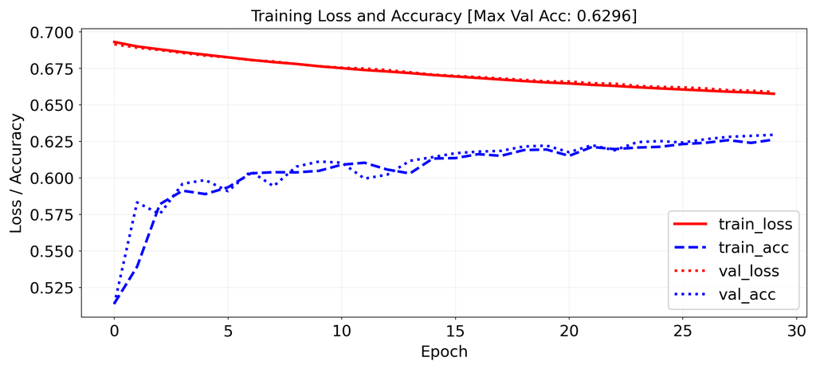

```
`Trainer.fit` stopped: `max_epochs=30` reached.
```

## Sequence-to-sequence (seq2seq) models

- Global average pooling or flattening destroys the word order
- We need to model sequences explictly, e.g.:
  - 1D convolutional models: run a 1D filter over the input data
    - Fast, but can only look at small part of the sentence
  - Recurrent neural networks (RNNs)
    - Can look back at the entire previous sequence
    - Much slower to train, have limited memory in practice
  - Attention-based networks (Transformers)
    - Best of both worlds: fast and very long memory

### seq2seq models

- Produce a series of output given a series of inputs over time
- Can handle sequences of different lengths
  - Label-to-sequence, Sequence-to-label, seq2seq,...
  - Autoregressive models (e.g. predict the next character, unsupervised)

[figure not shown]

### 1D convolutional networks

- Similar to 2D convnets, but moves only in 1 direction (time)
  - Extract local 1D patch, apply filter (kernel) to every patch
  - Pattern learned can later be recognized elsewhere (translation invariance)
- Limited memory: only sees a small part of the sequence (receptive field)
  - You can use multiple layers, dilations,... but becomes expensive
- Looks at 'future' parts of the series, but can be made to look only at the past
  - Known as 'causal' models (not related to causality)

[figure not shown]

```
model = nn.Sequential(
    nn.Embedding(num_embeddings=10000, embedding_dim=embedding_dim),
    nn.Conv1d(in_channels=embedding_dim, out_channels=32, kernel_size=7),
    nn.ReLU(),
    nn.MaxPool1d(kernel_size=5),
    nn.Conv1d(in_channels=32, out_channels=32, kernel_size=7),
    nn.ReLU(),
    nn.AdaptiveAvgPool1d(1),  # GAP
    nn.Flatten(),             # (batch, 32, 1) → (batch, 32)
    nn.Linear(32, 1)
)
```

### Recurrent neural networks (RNNs)

- Recurrent connection: concats output to next input ${\color{orange} h_t} = \sigma \left( {\color{orange} W } \left[ \begin{array}{c} {\color{blue}x}_t \\ {\color{orange} h}_{t-1} \end{array} \right] + b \right)$
- Unbounded memory, but training requires *backpropagation through time*
  - Requires storing previous network states (slow + lots of memory)
  - Vanishing gradients strongly limit practical memory
- Improved with *gating*: learn what to input, forget, output (LSTMs, GRUs,...)

[figure not shown]

### Simple self-attention

- Maps a *set* of inputs to a set of outputs (*without* learned weigths)

[figure not shown]

### Simple self-attention

- Compute dot product of input vector $x_i$ with every $x_j$ (including itself): ${\color{Orange} w_{ij}}$
- Compute softmax over all these weights (positive, sum to 1)
- Multiply by each input vector, and sum everything up
- Can be easily vectorized: ${\color{green} Y}^T = {\color{orange} W}{\color{blue} X^T}$, ${\color{orange} W} = \textrm{softmax}( {\color{blue} X}^T {\color{blue}X} )$

[figure not shown]

- For each output, we mix information from all inputs according to how 'similar' they are
  - The set of weights ${\color{Orange} w_{i}}$ for a given token is called the attention vector
  - It says how much 'attention' each token gives to other tokens
- Doesn't learn (no parameters), the embedding of ${\color{blue} X}$ defines self-attention
  - We'll learn how to *transform the embeddings* later
  - That way we can learn different relationships (not just similarity)
- Has no problem looking *very* far back in the sequence
- Operates on *sets* (permutation invariant): allows img-to-set, set-to-set,... tasks
  - If the token order matters, we'll have to encode it in the token embedding

[figure not shown]

### Scaled dot products

- Self-attention is powerful because it's mostly a linear operation
- ${\color{green} Y}^T = {\color{orange} W}{\color{blue} X^T}$ is *linear*, there are no vanishing gradients
  - The softmax function only applies to ${\color{orange} W} = \textrm{softmax}( {\color{blue} X}^T {\color{blue}X} )$, not to ${\color{green} Y}^T$
  - Needed to make the attention values sum up nicely to 1 without exploding
- The dot products do get larger as the embedding dimension $k$ gets larger (by a factor $\sqrt{k}$)
  - We therefore normalize the dot product by the input dimension $k$: ${\color{orange}w^{'}_{ij}} = \frac{{\color{blue} x_i}^T \color{blue} x_j}{\sqrt{k}}$
  - This also makes training more stable: large softmas values lead to 'sharp' outputs, making some gradients very large and others very small

### Simple self-attention layer

- Let's add a simple self-attention layer to our movie sentiment model
- Without self-attention, every word would contribute independently (bag of words)
  - The word *terrible* will likely result in a negative prediction
- Now, we can freeze the embedding, take output ${\color{gray}Y}$, obtain a loss, and do backpropagation so that the self-attention layer can *learn* that 'not' should invert the meaning of 'terrible'

[figure not shown]

### Simple self-attention layer

- Through training, we want the self-attention to learn how certain tokens (e.g. 'not') can affect other tokens / words.
  - E.g. we need to learn to change the representations of $v_{not}$ and $v_{terrible}$ so that they produce a 'correct' (low loss) output
- For that, we do need to add some trainable parameters.

[figure not shown]

### Standard self-attention

- We add 3 weight matrices (K, Q, V) and biases to change each vector:
  - $k_i = K x_i + b_k$
  - $q_i = Q x_i + b_q$
  - $v_i = V x_i + b_v$
- The same K, Q, V are used for all tokens depending on whether they are the input token (v), the token we are currently looking at (q), or the token we're comparing with (k)

[figure not shown]

### Sidenote on terminology

- View the set of tokens as a dictionary `s = {a: v_a, b: v_b, c: v_c}`
- In a dictionary, the third output (for key c) would simple be `s[c] = v_c`
- In a *soft* dictionary, it's a weighted sum: $s[c] = w_a * v_a + w_b * v_b + w_c * v_c$
- If $w_i$ are dot products: $s[c] = (k_a\cdot q_c) * v_a + (k_b\cdot q_c) * v_b + (k_b\cdot q_c) * v_c$
- We *blend* the influence of every token based on their learned relations with other tokens

[figure not shown]

### Intuition

- We *blend* the influence of every token based on their learned 'relations' with other tokens
- Say that we need to learn how 'negation' works
  - The 'query' vector could be trained (via Q) to say something like 'are there any negation words?'
  - A token (e.g. 'not'), transformed by K, could then respond very positively if it is

[figure not shown]

### Single-head self-attention

- There are different relations to model within a sentence.
- The same input token, e.g. $v_{terrible}$ can relate completely differently to other kinds of tokens
  - But we only have one set of K, V, and Q matrices
- To better capture multiple relationships, we need multiple self-attention operations (expensive)

[figure not shown]

### Multi-head self-attention

- What if we project the input embeddings to a lower-dimensional embedding $k$?
- Then we could learn multiple self-attention operations in parallel
- Effectively, we split the self-attention in multiple heads
  - Each applies a separate low-dimensional self attention (with $K^{kxk},Q^{kxk},V^{kxk}$)
- After running them (in parallel), we concatenate their outputs.

[figure not shown]

## Transformer model

- Repeat self-attention multiple times in controlled fashion
- Works for sequences, images, graphs,... (learn how sets of objects interact)
- Models consist of multiple transformer blocks, usually:
  - Layer normalization (every input is normalized independently)
  - Self-attention layer (learn interactions)
  - Residual connections (preserve gradients in deep networks)
  - Feed-forward layer (learn mappings)

[figure not shown]

### Positional encoding

- We need some way to tell the self-attention layer about position in the sequence
- Represent position by vectors, using some easy-to-learn predictable pattern
  - Add these encodings to vector embeddings
  - Gives information on how far one input is from the others
- Other techniques exist (e.g. relative positioning)

[figure not shown]

### Autoregressive models

- Models that predict future values based on past values of the same stream
- Output token is mapped to list of probabilities, sampled with softmax (with temperature)
- Problem: self-attention can simply look ahead in the stream
  - We need to make the transformer blocks *causal*

[figure not shown]

### Masked self-attention

- Simple solution: simply mask out any attention weights from current to future tokens
- Replace with -infinity, so that after softmax they will be 0

[figure not shown]

### Famous transformers

- "Attention is all you need": first paper to use attention without CNNs or RNNs
- Encoder-Decoder architecture for translation: (k, q) to source attention layer
- We'll reproduce this (partly) in the Lab 6 tutorial :)

[figure not shown]

### GPT 3

- Decoder-only, single stack of 96 transformer blocks (and 96 heads)
- Sequence size 2048, input dimensionality 12,288, 175B parameters
- Trained on entire common crawl dataset (1 epoch)
  - Additional training on high-quality data (Wikipedia,...)
- [Excellent animation by 1b3b](https://youtu.be/wjZofJX0v4M?t=305)
- [GPT from scratch by A. Karpathy](https://www.youtube.com/watch?v=kCc8FmEb1nY)

[figure not shown]

### GPT 4

- Likely a 'mixtures of experts' model
  - Router (small MLP) selects which subnetworks (e.g. 2) to use given input
  - Predictions get ensembled
- Allows scaling up parameter count without proportionate (inference) cost
- Also better data, more human-in-the-loop training (RLHF),...

[figure not shown]

## Vision transformers

- Same principle: split up into patches, embed into tokens, add position encoding
- For classification: add an extra (random) input token -> [CLS] output token

[figure not shown]

### Demonstration

We'll experiment with the CIFAR-10 datasets

- ViTs are quite expensive on large images.
- This ViT takes about an hour to train (we'll run it from a checkpoint)

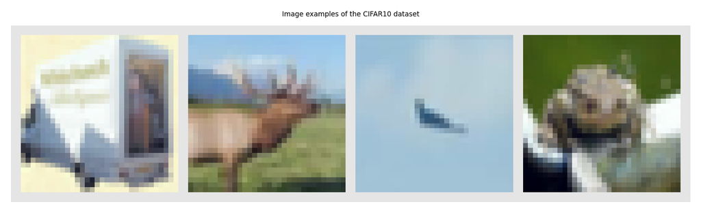

### Patchify

- Split $N\times N$ image into $(N/M)^2$ patches of size $M\times M$.

```
    B, C, H, W = x.shape  # Batch size, Channels, Height, Width
    x = x.reshape(B, C, H//patch_size, patch_size, W//patch_size, patch_size)
```

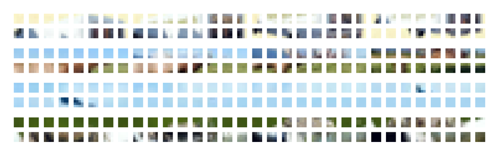

### Self-attention

First, we need to implement a (scaled) dot-product

[figure not shown]

### Self-attention

First, we need to implement a (scaled) dot-product

```
def scaled_dot_product(q, k, v):
    attn_logits = torch.matmul(q, k.transpose(-2, -1)) # dot prod
    attn_logits = attn_logits / math.sqrt(q.size()[-1])# scaling
    attention = F.softmax(attn_logits, dim=-1)         # softmax
    values = torch.matmul(attention, v)                # dot prod
    return values, attention
```

### Multi-head attention (simplified)

- Project input to lower-dimensional embeddings
- Stack them so we can feed them through self-attention at once
- Unstack and project back to original dimensions

```
    qkv = nn.Linear(input_dim, 3*embed_dim)(x) # project to embed_dim
    qkv = qkv.reshape(batch_size, seq_length, num_heads, 3*head_dim)
    q, k, v = qkv.chunk(3, dim=-1)

    values, attention = scaled_dot_product(q, k, v, mask=mask) # self-att
    values = values.reshape(batch_size, seq_length, embed_dim)
    out = nn.Linear(embed_dim, input_dim) # project back
```

### Attention block

The attention block is quite straightforward

[figure not shown]

### Attention block

```
def __init__(self, embed_dim, hidden_dim, num_heads, dropout=0.0):
    self.layer_norm_1 = nn.LayerNorm(embed_dim)
    self.attn = nn.MultiheadAttention(embed_dim, num_heads)
    self.layer_norm_2 = nn.LayerNorm(embed_dim)
    self.linear = nn.Sequential( # Feed-forward layer
        nn.Linear(embed_dim, hidden_dim),
        nn.GELU(), nn.Dropout(dropout),
        nn.Linear(hidden_dim, embed_dim),
        nn.Dropout(dropout)
    )
```

```
def forward(self, x):
    inp_x = self.layer_norm_1(x)
    x = x + self.attn(inp_x, inp_x, inp_x)[0] # self-att + res
    x = x + self.linear(self.layer_norm_2(x)) # feed-fw + res
    return x
```

## Vision transformer

Final steps:

- Linear projection (embedding) to map patches to vector
- Add classification token to input
- 2D positional encoding
- Small MLP head to map CLS token to prediction

[figure not shown]

[output not shown]

```
Found pretrained model at ../data/checkpoints/ViT.ckpt, loading...
```

[output not shown]

[output not shown]

```
ViT results {'test': 0.7713000178337097, 'val': 0.7781999707221985}
```

## Summary

- Tokenization
  - Find a good way to split data into tokens
- Word/Image embeddings (for initial embeddings)
  - For text: Word2Vec, FastText, GloVe
  - For images: MLP, CNN,...
- Sequence-to-sequence models
  - 1D convolutional nets (fast, limited memory)
  - RNNs (slow, also quite limited memory)
- Transformers
  - Self-attention (allows very large memory)
  - Positional encoding
  - Autoregressive models
- Vision transformers
  - Useful if you have lots of data (and compute)

Acknowledgement

Several figures came from the excellent [VU Deep Learning course](https://dlvu.github.io/).